# Lab 09 Gensim

# Load vectors using gensim

Example 1: Using gensim api

```python
#Load vectors using the gensim api
import gensim.downloader as api
word_vectors = api.load("glove-wiki-gigaword-100")  # load pre-trained word-vectors from gensim-data
```

```
[===================-------------------------------] 38.1% 48.7/128.1MB downloaded
```

[output not shown]

```
[==================================================] 100.0% 128.1/128.1MB downloaded
```

Find properties of data (similar, doesn't match, analogy)

```python
result = word_vectors.most_similar(positive=['woman', 'king'], negative=['man'])
print("{}: {:.4f}".format(*result[0]))
```

```
queen: 0.7699
```

```python
print(word_vectors.doesnt_match("breakfast cereal dinner lunch".split()))
```

```
cereal
```

```python
similarity = word_vectors.similarity('woman', 'man')
similarity> .80
```

```
True
```

```python
similarity> .90
```

```
False
```

```python
result = word_vectors.similar_by_word("cat")
print("{}: {:.4f}".format(*result[0]))
```

```
dog: 0.8798
```

```python
similarity = word_vectors.n_similarity(['france', 'russia'], ['paris'])
print(similarity)
```

```
0.6457069
```

Example: 2 Using gensim word2vec

This examples uses: vector_sm.txt

```python
!dir vector_sm.txt
```

```
/bin/bash: dir: command not found
```

**A line from vector.txt**  
71291 300  
</s> 0.001334 0.001473 -0.001277 ...  
santamaria -0.328541 0.143057 0.200979 0.176212 -0.043703 0.132309 -0.022670 0.268999 -0.098336  
Example as numpy array:  
array([0.7195499 , 0.34925455, 0. , 0.06428327, 0. ], dtype=float32)

```python
from gensim.models import Word2Vec
```

```python
#KeyedVectors is a mapping between entities and vectors.  Each entity is identified by its string id
#and is a mapping between str to 1D numpy array.
#Used your own vector file below.  You can also inclulde binary and change binary=True.
# Modify next line to add in your vector  (vector_sm.txt is a very small subset of data.)
model = gensim.models.KeyedVectors.load_word2vec_format('vector_sm(1).txt',binary=False)
#model = gensim.models.KeyedVectors.load_word2vec_format('vector.txt',binary=False)
```

```python
print(model)
```

```
KeyedVectors<vector_size=300, 71291 keys>
```

Examine the vocabulary as a numpy array

```python
pip install --upgrade gensim
```

```python
from gensim.models import KeyedVectors
```

```python
model.vocab
```

[output not shown]

Examine the shape of the matrix

```python
model.vectors.shape
```

```
(71291, 300)
```

Retrieve the vectors of individual words

```python
model['fire'].shape
```

```
(300,)
```

```python
model['house'][:10]
```

```
array([-1.662234,  0.604078, -3.122537,  1.535989,  1.123752,  0.031915,
       -1.284593,  0.07871 , -0.021927,  1.184942], dtype=float32)
```

```python
model['fire'][:10]
```

```
array([ 0.25062 , -0.420875, -1.628221, -1.038453,  0.557791,  0.478556,
        1.470237, -0.198495, -1.811532,  0.945193], dtype=float32)
```

```python
most_similar=model.most_similar(positive=['emperor', 'woman'], negative=['man'])
print(most_similar)
```

```
[('empress', 0.49833977222442627), ('emperors', 0.49494868516921997), ('theodora', 0.4320295453071594), ('fushimi', 0.42215171456336975), ('valentinian', 0.3999400734901428), ('empresses', 0.3943522572517395), ('suiko', 0.3869629502296448), ('pope', 0.3867180645465851), ('throne', 0.3856024742126465…
```

```python
most_similar2 = model.most_similar('queen', topn=5)
print(most_similar2)
```

```
[('elizabeth', 0.5374569892883301), ('king', 0.49853527545928955), ('boleyn', 0.45492687821388245), ('gracen', 0.45339253544807434), ('infanta', 0.4517417252063751)]
```

```python
distance = model.distance("media", "media")
print("{:.2f}".format(distance))
```

```
0.00
```

```python
analogy = model.most_similar(positive=['woman','king'],negative=['man'])
print(analogy)
```

```
[('queen', 0.5036637187004089), ('marries', 0.4303651750087738), ('betrothed', 0.42897987365722656), ('consort', 0.41862085461616516), ('daughter', 0.41833436489105225), ('anjou', 0.4096810221672058), ('infanta', 0.40592387318611145), ('heiress', 0.40402916073799133), ('montferrat', 0.40319895744323…
```

```python
import numpy as np
import gensim
# Get the interactive Tools for Matplotlib
%matplotlib notebook
import matplotlib.pyplot as plt
plt.style.use('ggplot')
from sklearn.decomposition import PCA
from gensim.test.utils import datapath, get_tmpfile
from gensim.models import KeyedVectors
from gensim.scripts.glove2word2vec import glove2word2vec
```

```python
def display_pca_scatterplot(model, words=None, sample=0):
    if words == None:
        if sample > 0:
            words = np.random.choice(list(model.vocab.keys()), sample)
        else:
            words = [ word for word in model.vocab ]
    word_vectors = np.array([model[w] for w in words])
    twodim = PCA().fit_transform(word_vectors)[:,:2]
    plt.figure(figsize=(6,6))
    plt.scatter(twodim[:,0], twodim[:,1], edgecolors='k', c='r')
    for word, (x,y) in zip(words, twodim):
        plt.text(x+0.05, y+0.05, word)
    for i in range(0, len(twodim), 2):
        plt.plot(twodim[:,0][i:i+2], twodim[:,1][i:i+2], 'bo-')
```

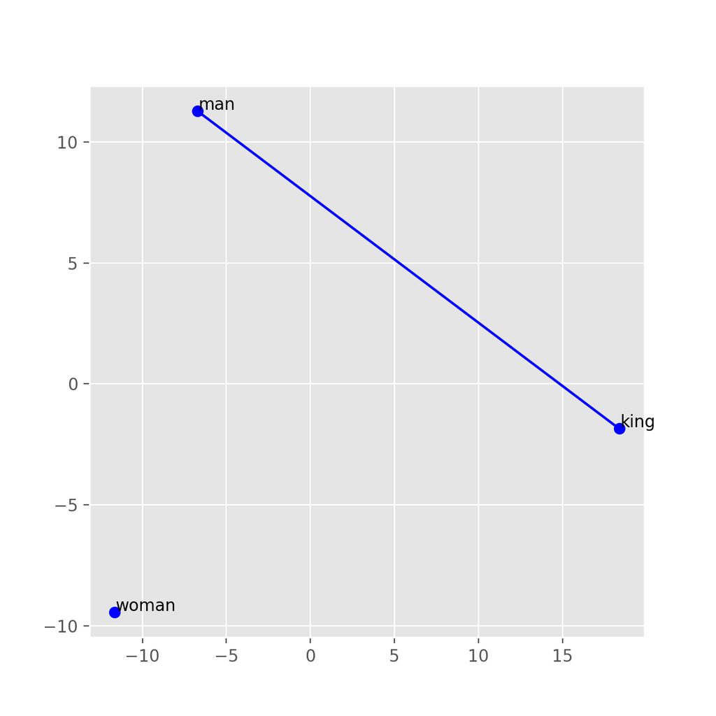

```python
#display_pca_scatterplot
display_pca_scatterplot(model,['king', 'man', 'woman'])
# display_pca_scatterplot(model,['king', 'man', 'woman','queen','boy','prince'])
```